# Título provisório

TCC 01

Autor

Alisson Lucas da Costa Santos

# 1 Introdução

A gestão prudente do risco de crédito constitui um dos pilares estratégicos de instituições financeiras, cuja rentabilidade e estabilidade dependem da capacidade de estimar com precisão a probabilidade de inadimplência (default) de solicitantes de empréstimos.

Decisões inadequadas na concessão acarretam perdas financeiras severas e exigem maior provisão para créditos de liquidação duvidosa, ao passo que critérios excessivamente restritivos penalizam o volume de negócios e a competitividade da instituição frente às demais.

Neste estudo, aborda-se o problema clássico de previsão da inadimplência a partir de um conjunto de dados composto por registros cadastrais, histórico financeiro e características das operações solicitadas por mais de 32 mil tomadores de crédito. A variável de interesse é dicotômica e representa o desfecho financeiro do empréstimo ($Y = 1$ para ocorrência de inadimplência e $Y = 0$ para quitação regular), configurando um cenário de classificação supervisionada em carteiras com desbalanceamento moderado entre as classes.

O objetivo central consiste em construir, avaliar e comparar modelos preditivos probabilísticos de regressão que identifiquem os fatores determinantes do risco de crédito e ofereçam poder discriminatório confiável para apoiar a esteira de concessão.

## 1.1 O conjunto de dados

Para abordar este problema, utilizaremos o conjunto de dados intitulado **Credit Risk Dataset**, disponibilizado na plataforma [Kaggle](https://www.kaggle.com/datasets/laotse/credit-risk-dataset?utm_source=gemini).

Este conjunto de dados contém colunas que simulam dados de órgãos de proteção ao crédito, reunindo informações cadastrais, histórico financeiro e detalhes sobre empréstimos tomados.

Cada observação representa uma contratação de empréstimo. No total o conjunto é composto por 32581 observações e 12 variáveis que se dividem em três grupos: perfil do tomador, características do empréstimo e informações de risco.

### 1.1.1 Perfil do tomador

No perfil do tomador, estão reunidas as seguintes variáveis:

- **Idade** (`person_age`): idade em anos.
- **Renda anual** (`person_income`): renda anual declarada (em unidade monetária).
- **Tipo de moradia** (`person_home_ownership`): situação de moradia atual, classificada em:
  - aluguel;
  - própria;
  - financiada;
  - outros.
- **Tempo no emprego atual** (`person_emp_length`): tempo de permanência no emprego atual (em anos).

### 1.1.2 Características do empréstimo

Em relação às características da operação de crédito, constam as seguintes variáveis:

- **Finalidade do empréstimo** (`loan_intent`): destinação do recurso tomado, classificada em:
  - uso pessoal;
  - educacional;
  - despesas médicas;
  - empreendimento;
  - reforma imobiliária;
  - quitação de dívidas.
- **Classificação de risco** (`loan_grade`): classificação atribuída à operação numa escala ordinal de “A” (menor risco) a “G” (maior risco).
- **Valor do empréstimo** (`loan_amnt`): montante financeiro total contraído.
- **Taxa de juros** (`loan_int_rate`): taxa de juros anual aplicada ao empréstimo.
- **Comprometimento da renda** (`loan_percent_income`): proporção entre o valor do empréstimo e a renda anual do tomador de crédito.

### 1.1.3 Informações de risco

Por fim, as seguintes variáveis associadas ao histórico de crédito estão disponíveis:

- **Inadimplência anterior** (`cb_person_default_on_file`): presença de registro de inadimplência prévia em birôs de crédito (“Sim” ou “Não”).
- **Histórico de crédito** (`cb_person_cred_hist_length`): tempo decorrido do primeiro registro de crédito em birôs (em anos).
- **Situação do empréstimo** (`loan_status`): variável de interesse (resposta), que indica o desfecho do pagamento do empréstimo ($0$ para adimplente/quitado e $1$ para inadimplente/*default*).

# 2 Análise exploratória

## 2.1 Desbalanceamento da variável resposta

Iniciaremos a nossa análise descritiva verificando o desbalanceamento da variável resposta.

## 2.2 Limpeza preliminar dos dados

Iniciaremos a nossa análise descritiva dos dados de risco de crédito fazendo uma limpeza preliminar no conjunto das variáveis quantitativas. Vamos começar conferindo o estado inicial do desbalanceamento da variável resposta, juntamente de duas tabelas com diversas medidas descritivas das variáveis quantitativas de acordo com a situação do empréstimo para que possamos rapidamente identificar possíveis inconsistências na base de dados.

A Figura 1 apresenta a distribuição da situação do empréstimo. Podemos observar que o desbalanceamento inicial é razoável, cerca de 78% para 21% a favor dos adimplentes

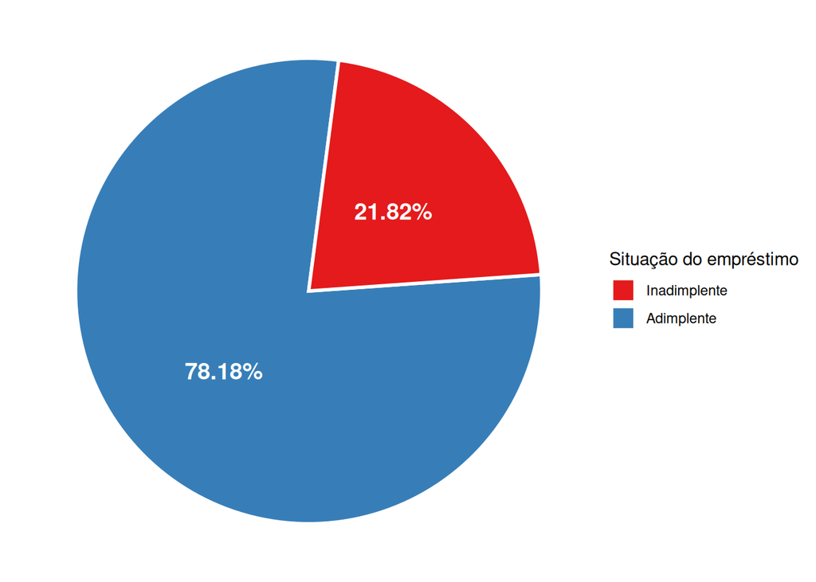

Figura 1: Distribuição da situação do empréstimo

A Tabela 1 e a Tabela 2 apresentam uma série de medidas resumo para as variáveis quantitativas, para adimplentes e inadimplentes, respectivamente.

Tabela 1: Medidas descritivas para adimplentes

| Variável | Média | Desvio padrão | Mínimo | $q_1$ | Mediana | $q_3$ | Máximo |
| --- | --- | --- | --- | --- | --- | --- | --- |
| Histórico de crédito (anos) | 5.84 | 4.04 | 2.00 | 3.00 | 4.00 | 8.00 | 30.00 |
| Valor do empréstimo | 9237.46 | 6026.38 | 500.00 | 5000.00 | 8000.00 | 12000.00 | 35000.00 |
| Taxa de juros | 10.44 | 2.98 | 5.42 | 7.68 | 10.59 | 12.69 | 22.06 |
| Comprometimento da renda | 0.15 | 0.09 | 0.00 | 0.08 | 0.13 | 0.20 | 0.83 |
| Idade | 27.81 | 6.37 | 20.00 | 23.00 | 26.00 | 30.00 | 144.00 |
| Tempo no emprego atual | 4.97 | 4.13 | 0.00 | 2.00 | 4.00 | 7.00 | 123.00 |
| Renda anual | 70804.36 | 66568.80 | 7000.00 | 42000.00 | 60000.00 | 84000.00 | 6000000.00 |

**Fonte**: base de dados.

Tabela 2: Medidas descritivas para inadimplentes

| Variável | Média | Desvio padrão | Mínimo | $q_1$ | Mediana | $q_3$ | Máximo |
| --- | --- | --- | --- | --- | --- | --- | --- |
| Histórico de crédito (anos) | 5.69 | 4.10 | 2.00 | 3.00 | 4.00 | 8.00 | 30.00 |
| Valor do empréstimo | 10850.50 | 7143.35 | 900.00 | 5000.00 | 9600.00 | 15000.00 | 35000.00 |
| Taxa de juros | 13.06 | 3.29 | 5.42 | 10.74 | 13.49 | 15.58 | 23.22 |
| Comprometimento da renda | 0.25 | 0.13 | 0.01 | 0.14 | 0.24 | 0.34 | 0.78 |
| Idade | 27.47 | 6.26 | 20.00 | 23.00 | 26.00 | 30.00 | 70.00 |
| Tempo no emprego atual | 4.14 | 4.13 | 0.00 | 1.00 | 3.00 | 6.00 | 123.00 |
| Renda anual | 49125.65 | 36907.38 | 4000.00 | 30000.00 | 41498.00 | 59497.75 | 703800.00 |

**Fonte**: base de dados.

Inspecionando brevemente as medidas das tabelas, não há dados negativos, porém detecta-se problemas lógicos em duas variáveis: idade do tomador e tempo no emprego atual. O máximo dessas variáveis revela outliers situados a uma distância consideravelmente alta do 3º quartil de suas respectivas distribuições, que torna o dado implausível quando confrontado com a natureza lógica da variável. Por exemplo, é biologicamente impossível que uma pessoa tenha mais de 140 anos (Tabela 1) ou tenha permanecido no mesmo emprego por 123 anos (Tabela 1 e Tabela 2).

Alguns desses pontos discrepantes podem representar erros cadastrais e de mensuração ou, alternativamente, revelar valores atípicos extremos legítimos, a exemplo da expressiva renda anual máxima observada de 6000000. No entanto, independentemente do motivo, a presença destes outliers pode distorcer a interpretação do comportamento real da população e comprometer qualquer inferência realizada sobre os dados. Daí surge a necessidade de analisar e tratar individualmente estas variáveis.

Além disso, detectou-se a existência de dados faltantes em duas variáveis: taxa de juros e tempo de emprego atual. O número de observações faltantes em cada uma destas duas variáveis juntamente com a proporção de perda em relação ao tamanho da amostra ($n = 32581$) é apresentado no gráfico de barras a seguir.

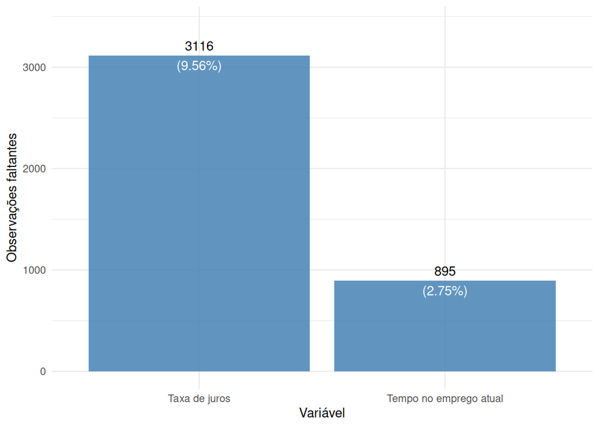

Figura 2: Composição de valores faltantes por variável em relação à base de dados

A princípio, optamos pela simples remoção destas observações faltantes da base de dados. O principal motivo é a potencial conveniência estatística disponível neste conjunto de dados em específico.

Embora a remoção destas observações faltantes possa parecer, do ponto de vista metodológico, uma razoável perda em termos percentuais da informação da amostra (quase 10% pela taxa de juros), trata-se na verdade de uma perda amostral marginal que não compromete a representatividade dos dados. O tamanho resultante da amostra após a remoção ainda é muito alto, possuindo mais de 25 mil observações remanescentes, sendo mais que o suficiente para uma infereência adequada que permita a obtenção de modelos preditivos sem prejudicar a qualidade deles.

Além disso, será visto mais adiante pela Figura 4 que o desbalanceamento da varíavel resposta não é afetado de maneira significativa com esta decisão e nem com a próxima, que é relacionada com os pontos discrepantes do conjunto de dados.

A Figura 3 apresenta uma comparação das distribuições da idade e tempo de emprego por meio de dois box plots lado a lado.

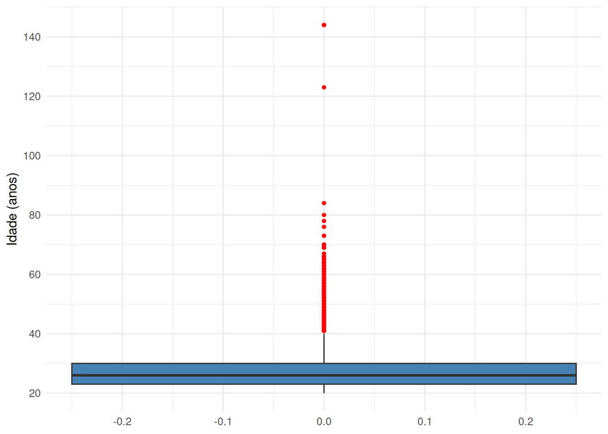

(a) Distribuição das idades dos tomadores de crédito

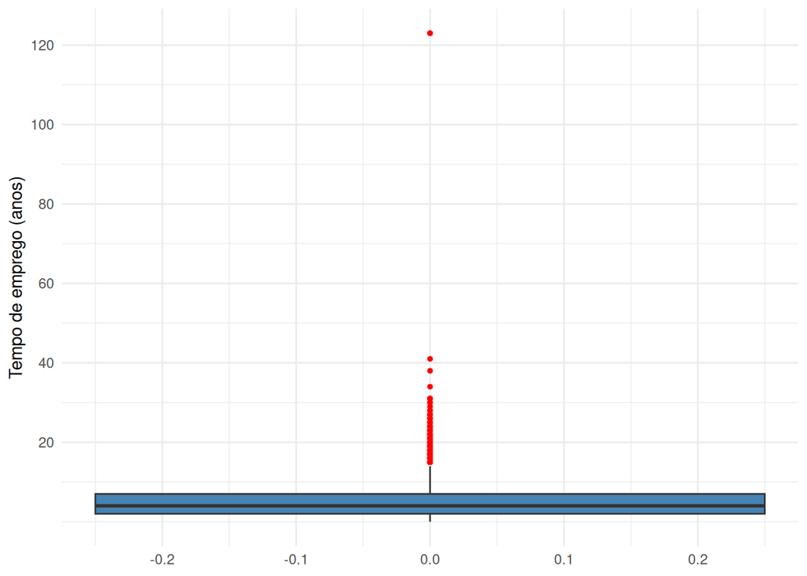

(b) Distribuição dos tempos de emprego dos tomadores de crédito

Figura 3: Distribuição das idades e tempos de emprego dos tomadores de crédito (prévia)

Geralmente no mundo da concessão de empréstimos, as instituições financeiras operam prioritariamente na faixa de 18 a 80 anos. O piso de 18 anos é baseado na idade mínima legal para operar no mercado financeiro, enquanto que o teto de 80 anos fundamenta-se nas práticas do mercado financeiro, no qual concessões acima dessa idade envolvem regras operacionais e limites estritos de elegibilidade securitária.

Poderíamos então seguir o comportamento convencional já estabelecido no mercado, assegurado por esta justificativa apresentada. Contudo, neste estudo, nos propomos a trabalhar com a modelagem de regressão para previsão da incidência de inadimplência em empréstimos restrita a um público mais jovem, na faixa etária de 20 a 40 anos. Consideramos a idade mínima para começar a trabalhar como sendo 16 anos, padrão adotado pela maioria dos países. Naturalmente, isso implica na remoção de quaisquer observações em que a diferença entre a idade e o tempo de emprego seja inferior a 16 anos, cenário que seria infactível dentro do critério adotado.

Há algumas razões para esta escolha. Em primeiro lugar, a grande maioria dos empréstimos no mundo financeiro costuma ser solicitados nas primeiras décadas da vida adulta, principalmente por jovens adultos e profissionais em consolidação de carreira. Portanto, a restrição a este intervalo etário possibilita o aprimoramento da modelagem estatística voltada a um público mais importante para as instituições financeiras.

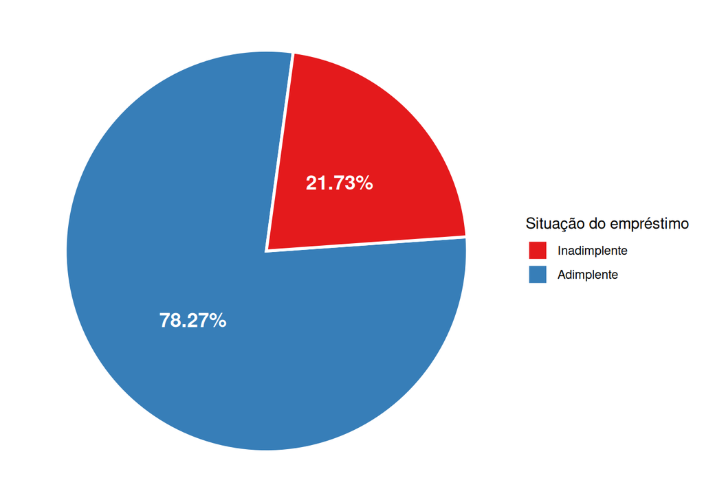

Figura 4: Distribuição da situação do empréstimo

Ainda no âmbito das inconsistências das idades, verificou-se que não havia observações em que a idade era inferior ao tempo no emprego atual e tampouco era inferior ao histórico de crédito. Por fim, foi calculada a razão entre o valor do empréstimo e a renda anual do tomador e obteve-se a diferença absoluta com os valores correspondentes da variável do comprometimento da renda. A maior diferença observada foi de 0.0933824, possivelmente causado por erros de arredondamento. Por conveniência, optou-se por continuar utilizando a variável de comprometimento de renda original.

Após a constação das inconsistências e a remoção das 5899 observações apuradas, elaborou-se uma versão atualizada de medidas descritivas para todas as variáveis quantitativas, de acordo com a situação do empréstismo.

Tabela 3: Medidas descritivas para adimplentes

| Variável | Média | Desvio padrão | Mínimo | $q_1$ | Mediana | $q_3$ | Máximo |
| --- | --- | --- | --- | --- | --- | --- | --- |
| Histórico de crédito (anos) | 5.38 | 3.35 | 2.00 | 3.00 | 4.00 | 7.00 | 17.00 |
| Valor do empréstimo | 9242.96 | 6024.38 | 500.00 | 5000.00 | 8000.00 | 12000.00 | 35000.00 |
| Taxa de juros | 10.47 | 2.97 | 5.42 | 7.74 | 10.62 | 12.69 | 22.06 |
| Comprometimento da renda | 0.15 | 0.09 | 0.00 | 0.08 | 0.13 | 0.20 | 0.83 |
| Idade | 26.94 | 4.54 | 20.00 | 23.00 | 26.00 | 30.00 | 40.00 |
| Tempo no emprego atual | 4.77 | 3.83 | 0.00 | 2.00 | 4.00 | 7.00 | 24.00 |
| Renda anual | 69952.85 | 47271.70 | 7200.00 | 42000.00 | 60000.00 | 84000.00 | 1200000.00 |

**Fonte**: base de dados.

Tabela 4: Medidas descritivas para inadimplentes

| Variável | Média | Desvio padrão | Mínimo | $q_1$ | Mediana | $q_3$ | Máximo |
| --- | --- | --- | --- | --- | --- | --- | --- |
| Histórico de crédito (anos) | 5.22 | 3.32 | 2.00 | 3.00 | 4.00 | 7.00 | 17.00 |
| Valor do empréstimo | 10927.87 | 7102.95 | 900.00 | 5000.00 | 9975.00 | 15000.00 | 35000.00 |
| Taxa de juros | 13.11 | 3.26 | 5.42 | 10.83 | 13.49 | 15.58 | 23.22 |
| Comprometimento da renda | 0.25 | 0.13 | 0.01 | 0.14 | 0.24 | 0.34 | 0.78 |
| Idade | 26.62 | 4.51 | 20.00 | 23.00 | 25.00 | 29.00 | 40.00 |
| Tempo no emprego atual | 3.95 | 3.66 | 0.00 | 1.00 | 3.00 | 6.00 | 23.00 |
| Renda anual | 49697.54 | 36680.29 | 4080.00 | 30000.00 | 42000.00 | 60000.00 | 703800.00 |

**Fonte**: base de dados.

## 2.3 Análise individual

Iremos agora nos restringir a uma análise individual de cada variável quantitativa, em termos de distribuição geral, presença de pontos extremos e distribuição condicionada ao status da variável de interesse. Em seguida, iremos tratar das variáveis qualitativas.

Após esta etapa, prosseguiremos com uma análise conjunta das variáveis e finalizaremos nossa exploração com um estudo de valores faltantes na base de dados.

### 2.3.1 Idade

A Figura 5 mostra que a parte central das distribuições da idade dos tomadores de crédito entre os grupos de adimplentes e inadimplentes é muito similar. Ambos os grupos possuem uma maior amplitude na parte superior da distribuição, acima da mediana. Isto pode ser um indicativo de que a idade por si só não é tão informativa para saber se o tomador vai ou não quitar a dívida.

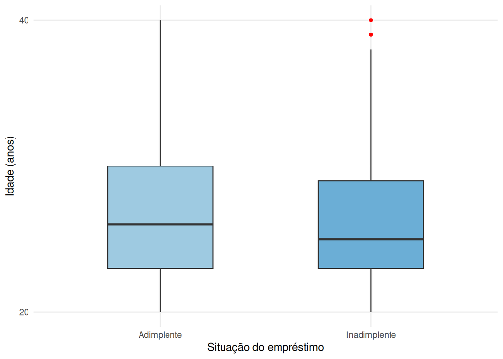

Figura 5: Distribuição das idades por situação de empréstimo

Ao avaliar o histograma da Figura 6 podemos confirmar que se trata de uma distribuição assimétrica à direita e a maioria dos empréstimos está situado na classe de 22 a 27 anos.

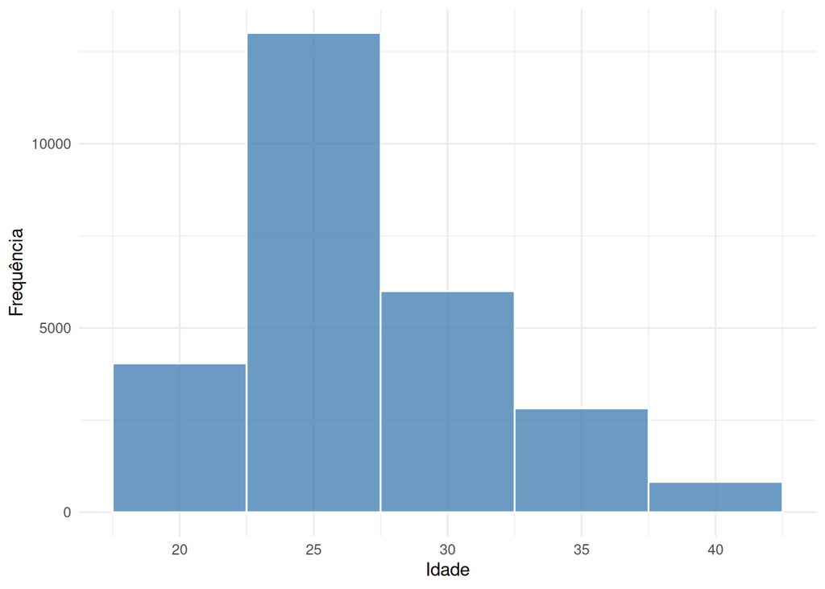

Figura 6: Distribuição das idades

### 2.3.2 Renda anual

A renda anual apresenta acentuada assimetria positiva, caracterizada por uma cauda longa e distante da mediana, evidenciada pela expressiva concentração de outliers na porção superior da Figura 7. O coeficiente de curtose de 74.82 atesta o padrão fortemente leptocúrtico da distribuição, confirmando o peso excessivo da cauda em relação a uma distribuição normal.

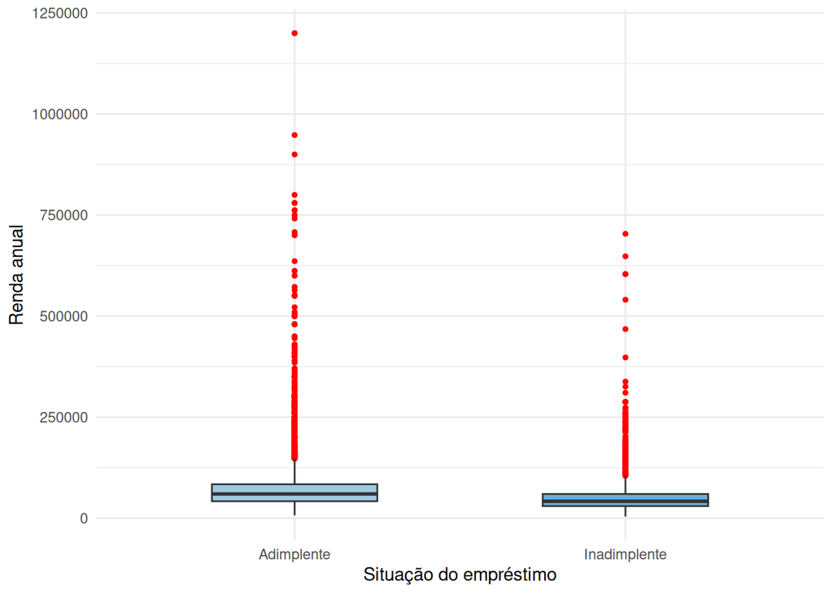

Figura 7: Distribuição da renda anual por situação de empréstimo

Diante destes sintomas, investigou-se a distribuição da variável sob a transformação do logaritmo natural, já que a renda em escala bruta quase certamente colocaria em risco o desempenho de qualquer modelo de regressão devido a um alto grau de alavancagem. A justificativa é suportada principalmente por dois motivos. O primeiro e mais importante diz respeito à teoria econômica que descreve que o ganho na capacidade de pagamento decorre de acréscimos percentuais na renda e não de aumentos nominais fixos. O segundo motivo é permitir a compressão da cauda longa e estabilização da escala, procedimento plenamente viabilizado pela ausência de valores nulos ou negativos na distribuição empírica da variável.

A inspeção visual dos histogramas da Figura 8 comprova a eficácia da transformação. O segundo histograma agora possui caudas muito mais leves se comparado ao primeiro.

[figure not shown]

(a) Escala bruta

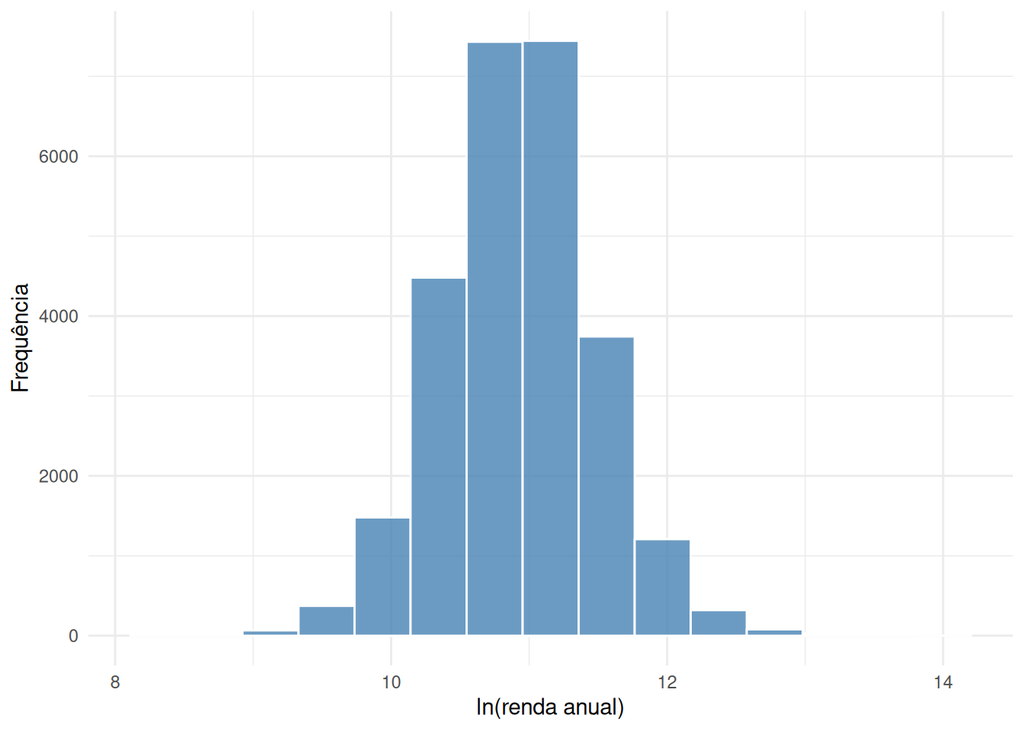

(b) Escala logarítmica (ln)

Figura 8: Distribuição da renda anual em escala original e logarítmica

A escala logarítmica reduz a curtose dos dados de 74.82 para 4 e possui um coeficiente de assimetria de 0.12, que descreve uma distribuição muito mais simétrica.

### 2.3.3 Tempo no emprego atual

[figure not shown]

Figura 9: Distribuição dos tempos no emprego do tomador por situação de empréstimo

O gráfico de barras da Figura 10 mostra que a variável possui uma distribuição assimétrica positiva, com cauda pesada à direita. Chama a atenção a manifestação de um fenômeno natural na variável: pessoas desempregadas são as que mais tomam empréstismos, e isso pode ser observado na figura.

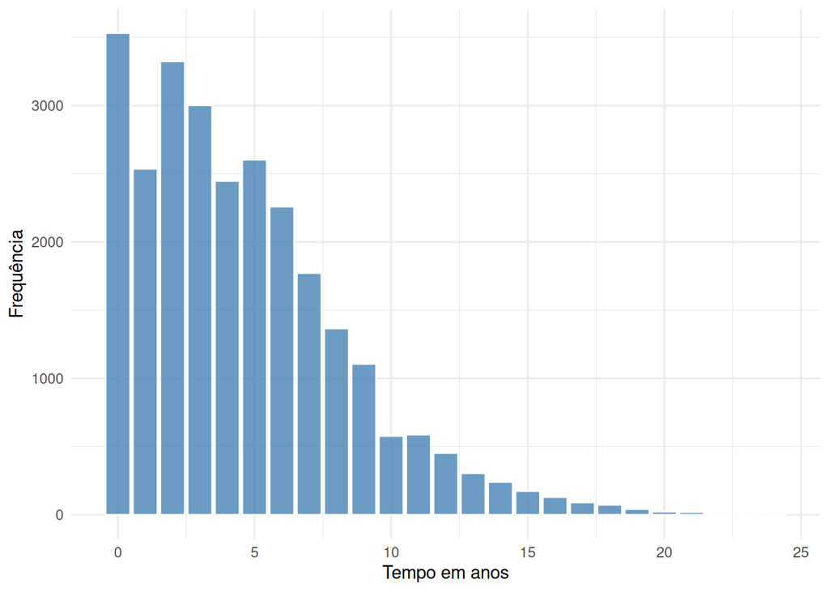

Figura 10: Distribuição dos tempos no emprego do tomador

### 2.3.4 Valor do empréstimo

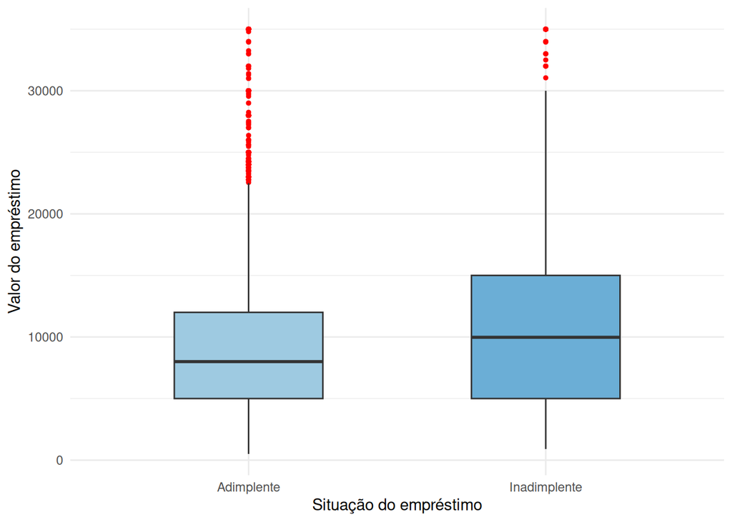

Figura 11: Distribuição dos empréstimos por situação de empréstimo

O histograma aponta que a maior parte dos empréstimos estão concentrados na metade esquerda do gráfico. Há um número razoável de empréstimos de até 25 mil. Concessão de empréstimos acima desse valor decaem drasticamente.

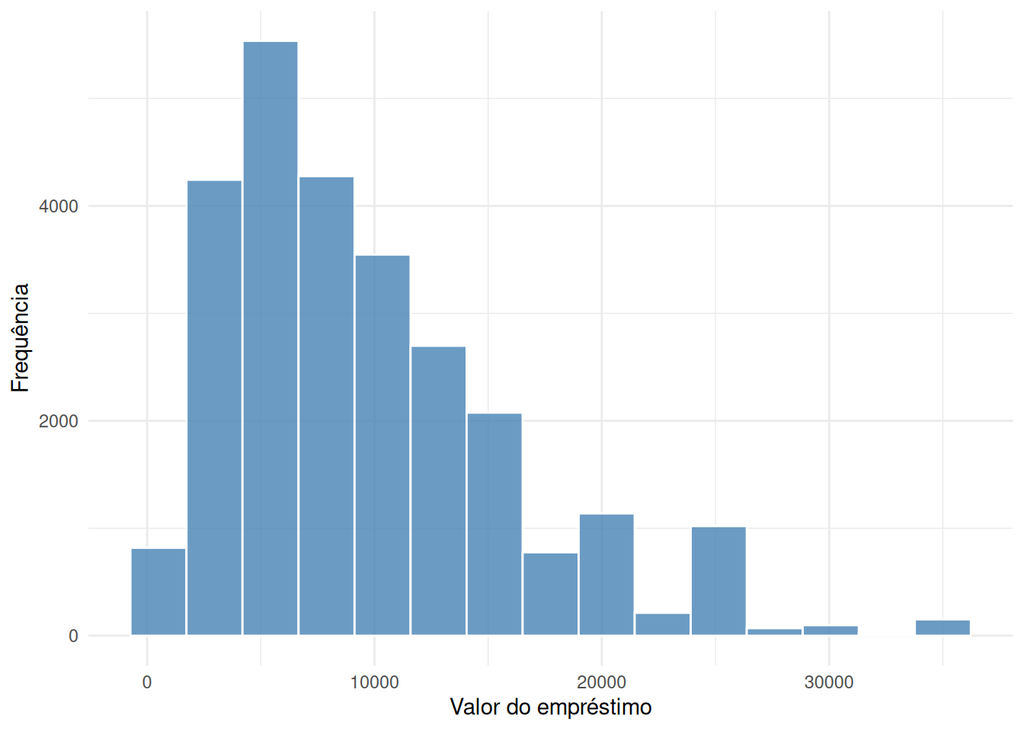

Figura 12: Distribuição dos empréstimos

### 2.3.5 Taxa de juros

A relação da taxa de juros com o status de inadimplência é bem clara. Como exibido na Figura 13, o grupo de inadimplementes, por representarem um risco maior às instituições financeiras, contraem empréstimos com taxas de juros significativamente mais altas se comparado com o grupo dos que pagam em dia.

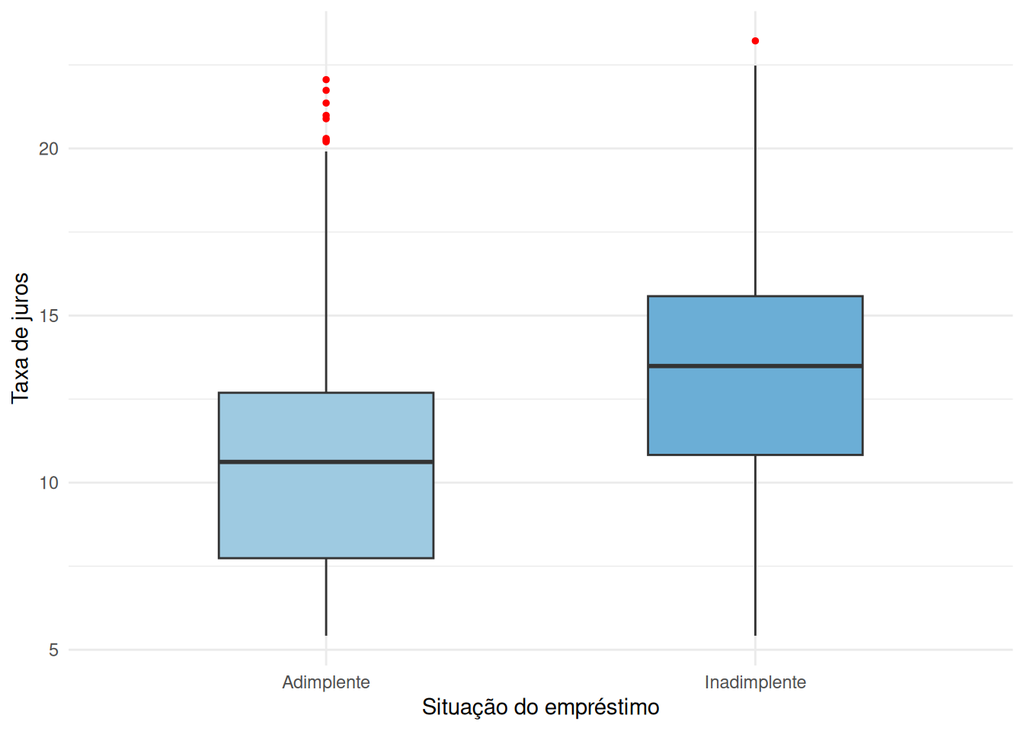

Figura 13: Distribuição das taxas de juros dos empréstimos contratados por situação de empréstimo

Já o histograma da taxa de juros demonstra que esta variável poussi uma assimetria positiva bem mais atenuada e uma cauda direta mais suave.

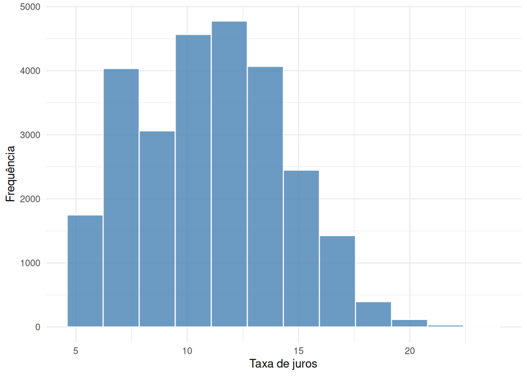

Figura 14: Distribuição das taxas de juros dos empréstimos contratados

### 2.3.6 Comprometimento da renda

Em relação ao comprometimento da renda, que é a razão entre o valor do empréstimo sobre a renda anual do indivíduo, podemos observar pela Figura 15 que as pessoas que não quitaram seus empréstimos comprometem mais a sua renda quando contraem esses empréstimos se comparado com os grupos que quitaram a dívida. É um comportamento semelhante a da taxa de juros, em que os 3 quartis do segundo grupo são maiores que os do primeiro.

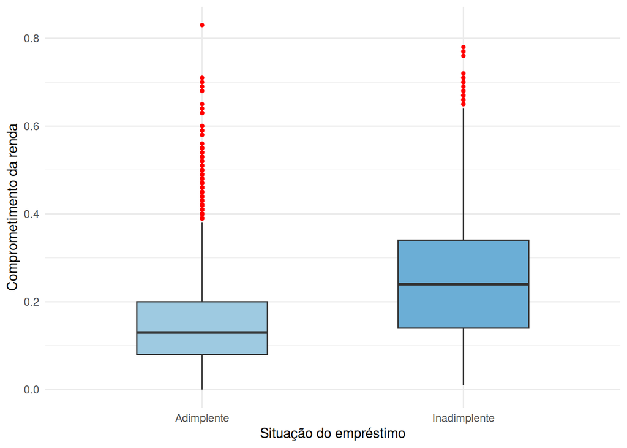

Figura 15: Distribuição do comprometimento da renda por situação de empréstimo

Enquanto os adimplentes costumam comprometer até 40% de suas rendas, os inadimplementes comprometem até um pouco mais de 60% de suas rendas. Isto sem levar em conta os pontos exteriores (possíveis outliers).

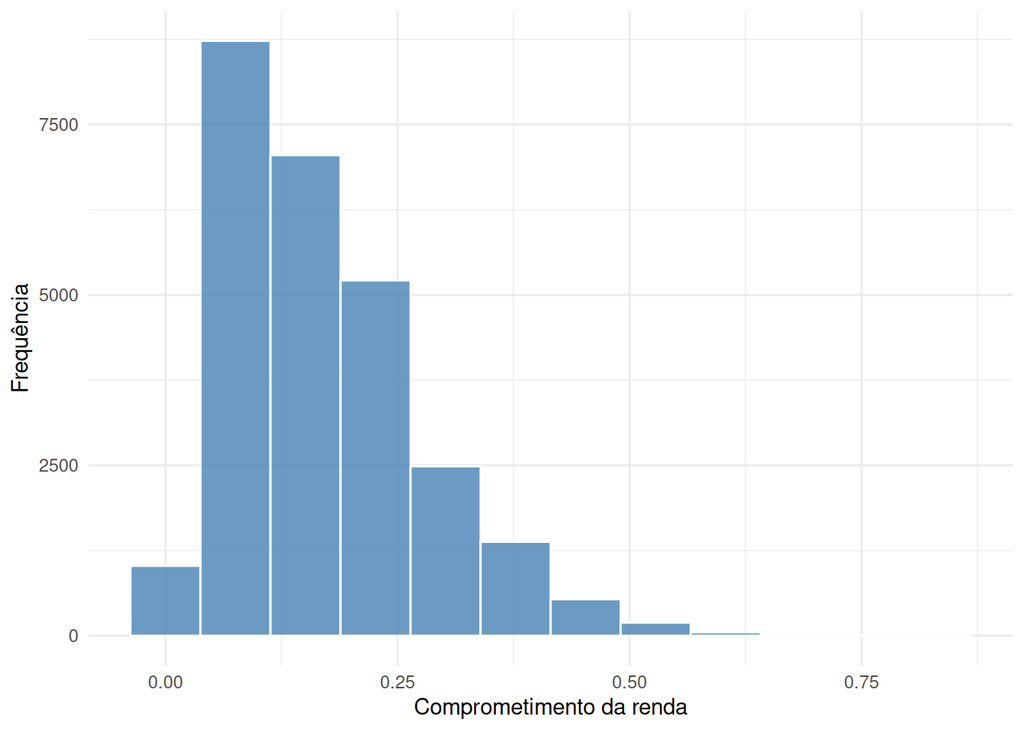

Figura 16: Distribuição do comprometimento da renda

### 2.3.7 Histórico de crédito

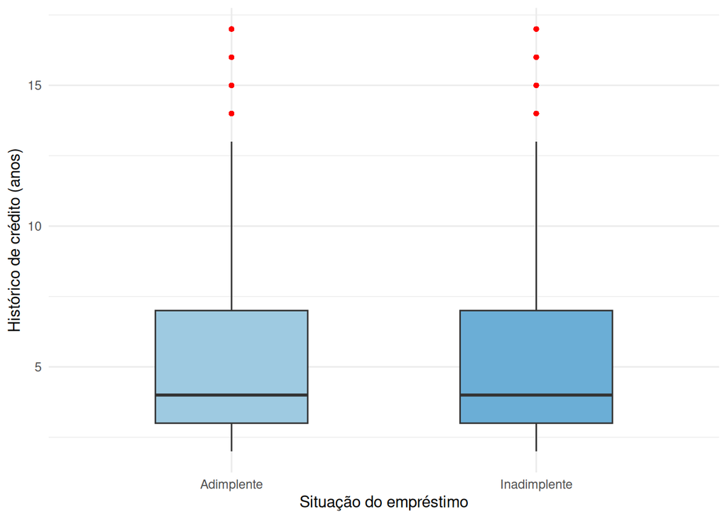

Figura 17: Distribuição do histórico de crédito por situação de empréstimo

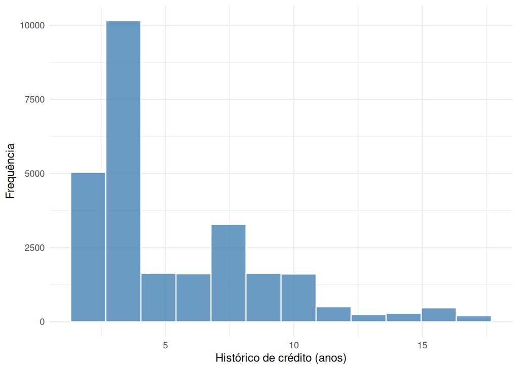

Figura 18: Distribuição do histórico de crédito

### 2.3.8 Tipo de moradia

De acordo com a Figura 19, os dois grupos que mais contratam empréstimos são as pessoas com casas alugadas e financiadas.

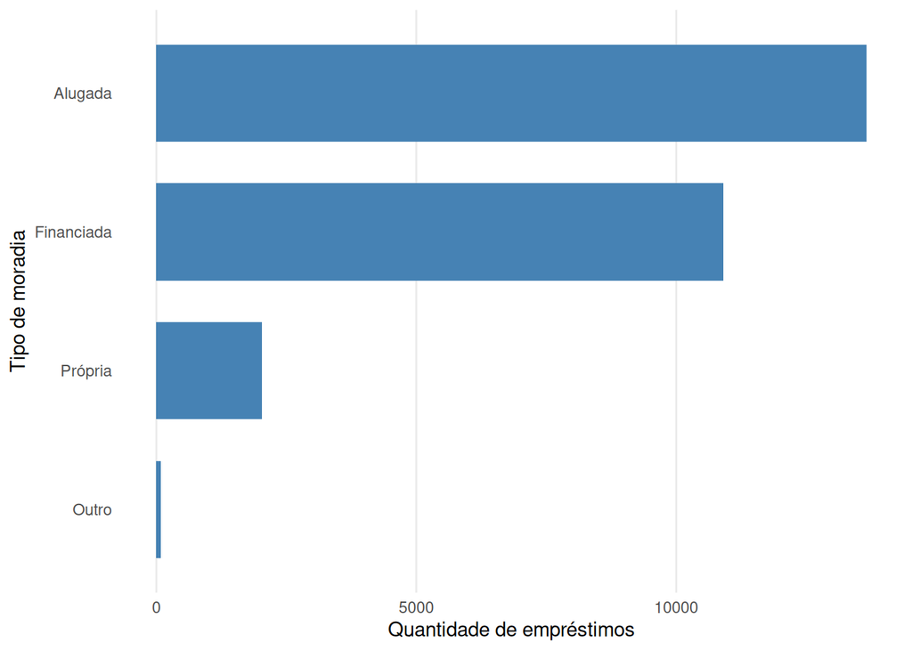

Figura 19: Distribuição do tipo de moradia

Se observamos a distribuição conjunta da situação do empréstimo de acordo com o tipo de moradia, descrito na Tabela 5, notamos que o percentual de inadimplentes dentro do grupo dos que possuem possuem imóvel alugado é mais do que 4x o percentual de inadimplentes do grupo que possui moradia própria. Também é constatado diferenças expressivas entre os demais grupos de moradia. Este é um bom indicativo de que existe uma relação concreta entre o tipo de moradia e a variável resposta situação do empréstimo.

Tabela 5: Distribuição conjunta das proporções da situação de empréstimo conforme o tipo de moradia do tomador

| Tipo de moradia | Situação do empréstimo (%) Adimplente | Situação do empréstimo (%) Inadimplente | Situação do empréstimo (%) Total |
| --- | --- | --- | --- |
| Alugada | 68.85 | 31.15 | 100 |
| Financiada | 87.34 | 12.66 | 100 |
| Própria | 93.22 | 6.78 | 100 |
| Outro | 70.93 | 29.07 | 100 |

**Fonte**: base de dados.

### 2.3.9 Finalidade do empréstimo

Em termos de destinação dos recursos, segundo a Figura 20, o top 3 é composto por investimentos em educação seguido por despesas médicas e empreendimento.

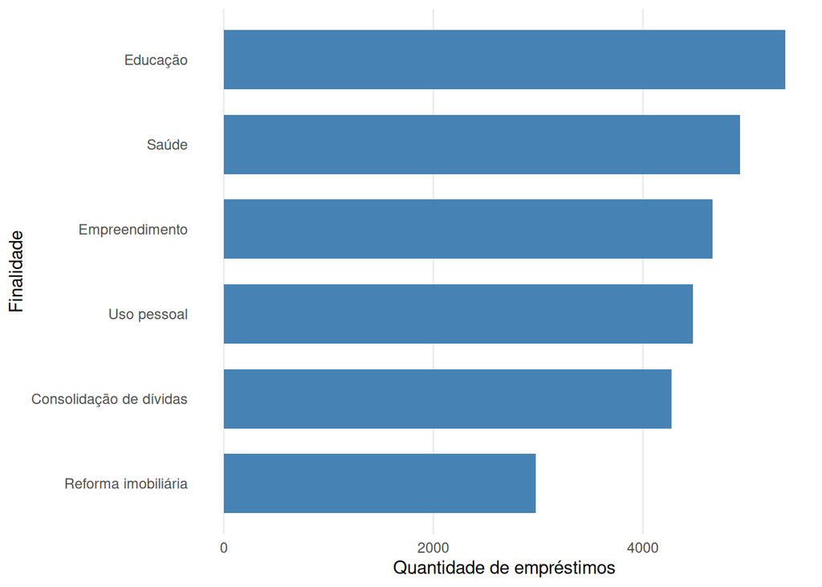

Figura 20: Distribuição da finalidade do empréstimo

Conforme descrito pela Tabela 6, a proporção de inadimplentes é maior em empréstimos tomados com a finalidade de quitação de dívidas, reforma imobiliária e despesas médicas.

Tabela 6: Distribuição conjunta das proporções da situação de empréstimo conforme a finalidade

| Finalidade | Situação do empréstimo (%) Adimplente | Situação do empréstimo (%) Inadimplente | Situação do empréstimo (%) Total |
| --- | --- | --- | --- |
| Consolidação de dívidas | 72.10 | 27.90 | 100 |
| Educação | 83.11 | 16.89 | 100 |
| Reforma imobiliária | 73.77 | 26.23 | 100 |
| Saúde | 73.20 | 26.80 | 100 |
| Uso pessoal | 79.95 | 20.05 | 100 |
| Empreendimento | 84.96 | 15.04 | 100 |

**Fonte**: base de dados.

### 2.3.10 Classificação de risco

A distribuição das contratações por grau de risco (Figura 21) evidencia um comportamento esperado no mercado de crédito: o volume de operações concedidas decresce monotonicamente à medida que o risco de inadimplência atribuído ao tomador se eleva.

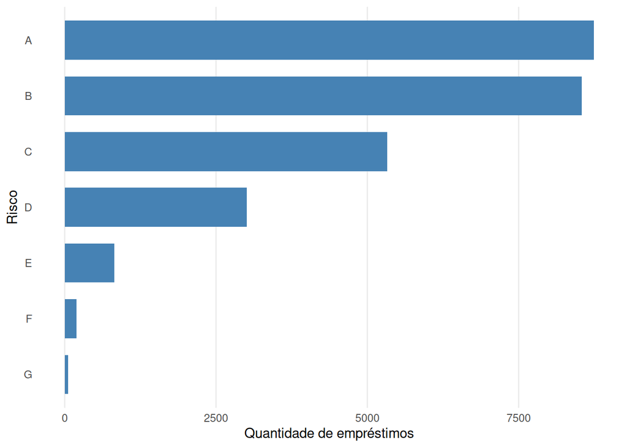

Figura 21: Distribuição da classificação de risco

Como esperado para uma régua de classificação de crédito, observa-se na Tabela 7 uma relação direta entre o grau de risco e a taxa de inadimplência. Esse padrão confirma a elevada capacidade discriminatória da variável para a modelagem do risco de crédito.

Tabela 7: Distribuição conjunta das proporções da situação de empréstimo conforme a classificação de risco

| Risco | Situação do empréstimo (%) Adimplente | Situação do empréstimo (%) Inadimplente | Situação do empréstimo (%) Total |
| --- | --- | --- | --- |
| A | 90.26 | 9.74 | 100 |
| B | 84.16 | 15.84 | 100 |
| C | 79.60 | 20.40 | 100 |
| D | 40.55 | 59.45 | 100 |
| E | 35.01 | 64.99 | 100 |
| F | 29.53 | 70.47 | 100 |
| G | 1.89 | 98.11 | 100 |

**Fonte**: base de dados.

### 2.3.11 Registro de inadimplência anterior

Cerca de 4765 (17.86%) dos empréstimos concedidos a pessoas que já possuíam registro de inadimplência em seus históricos, enquanto que 21917 (82.14%) dos empréstimos foram concedidos a pessoas que sempre pagam em dia.

A Tabela 8 demonstra que a proporção de inadimplentes no grupo dos que já foram inadimplentes no passado é basicamente o dobro do grupo dos que nunca ficaram devendo.

Tabela 8: Distribuição conjunta das proporções da situação de empréstimo conforme o registro de inadimplência anterior

| Registro | Situação do empréstimo (%) Adimplente | Situação do empréstimo (%) Inadimplente | Situação do empréstimo (%) Total |
| --- | --- | --- | --- |
| Sim | 62.31 | 37.69 | 100 |
| Não | 81.74 | 18.26 | 100 |

**Fonte**: base de dados.

### 2.3.12 Situação do empréstimo

Na amostra saneada, nossa variável resposta revela que 5799 (21.73%) dos empréstimos concedidos tiveram um desfecho de inadimplência na base de dados, ao passo que apenas 20883 (78.27%) do total de 26682 empréstimos foram devidamente quitados.

## 2.4 Análise conjunta

Agora iremos investigar a existência de relações entre as potenciais variáveis preditoras. Mais especificamente, iremos concentrar nossa atenção para as correlações entre as variáveis numéricas e as distribuições conjuntas entre pares de variáveis categóricas por meio da inspeção visual de gráficos de barras empilhados.

### 2.4.1 Variáveis quantitativas

A matriz de correlação linear exibida na Figura 22 revela predomínio de associações fracas a nulas entre a maioria das variáveis explicativas numéricas, indicando baixo risco generalizado de redundância de informação. Destacam-se, contudo, dois pares específicos: a forte associação entre idade e tempo de histórico de crédito ($r > 0.80$), e a correlação positiva entre o montante do empréstimo e o comprometimento da renda ($r > 0.5$). Ambos os casos serão monitorados quanto a possíveis impactos de multicolinearidade nas etapas de ajuste do modelo preditivo.

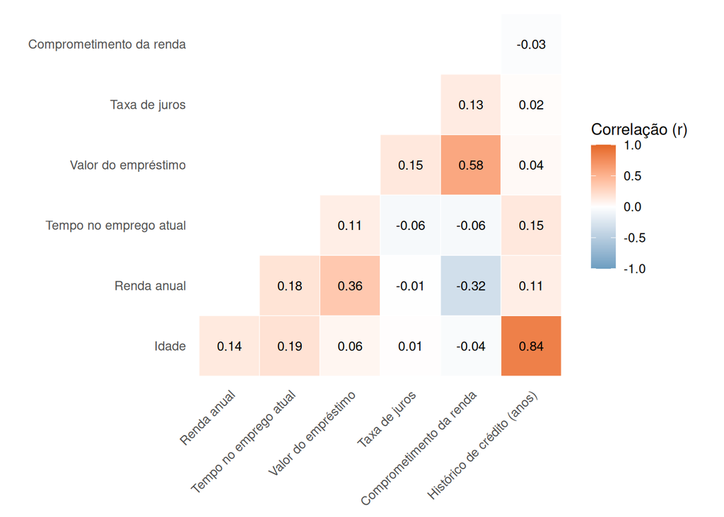

Figura 22: Matriz de correlação

### 2.4.2 Variáveis categóricas

A Figura 23 apresenta as distribuições entre os pares das variáveis categóricas: tipo de moradia, finalidade do empréstimo, nível de risco e registro de inadimplência anterior. Nota-se que praticamente todos os pares de preditores categóricos apresentam distribuições homogêneas e independentes entre si. A principal exceção reside no cruzamento entre nível de risco e registro de inadimplência anterior, no qual as faixas de menor risco (A e B) exibem ausência quase total de registros negativos em comparação às categorias mais arriscadas.

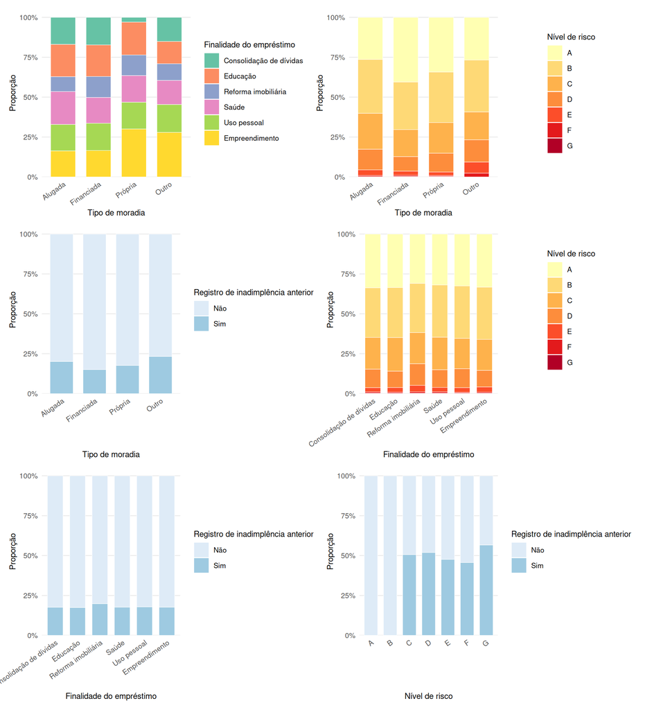

Figura 23: Distribuição proporcional entre pares de variáveis categóricas explicativas

## 2.5 Dados faltantes

Com o estudo das relações entre as variáveis e a remoção de observações inválidas finalizadas, focaremos agora em um detalhe crucial no aspecto da qualidade e consistência dos dados da amostra, a existência de mensurações faltantes em uma ou mais variáveis.

**Como vamos reinputar esses dados na amostra?**

Possíveis técnicas para considerar:

- imputação simples por medida de tendência central com média ou mediana,
- imputação por agrupamento condicional (mediana por grupos),
- imputação baseada em modelos/algoritmos (k-nn, random forest ou mice),
- outros.